# Meteorological Data Analysis - Hourly data

Henry Perillo

7/27/2020

This R Markdown File details the methodology used to analyze meteorological data (from the Dublin Airport Met Eirann Station) across January, February, March, April, May, and June for the years 2017-2020. The aim of this analysis is to determine a month or months (if any) that do not display a signficiant difference in average hourly precipitation (in millimeters), or average hourly windspeed (in m/s). Such month can be used to more confidently attribute differences in pollution concentration to lockdown protocols, rather than meterological factors.

# Data Input

Library packages:

```r
# Clear R Studio environment
rm(list = ls())

# Load packages
library(dplyr)
library(readr)
library(tidyr)
library(stringr)
library(ggplot2)
library(data.table)
library(rio)
library(purrr)
library(rmweather)
library(ranger)
library(hexbin)
library(lubridate)
library(ggplot2)
library(Rmisc)
```

Load weather data:

```r
# Set working directory.
setwd("~/Desktop/Research_Project/Data/AQ/Preliminary_Data")

# Load csv
Weather <- read_csv("Hourly_Met_Data_Dublin_Airport.csv")
```

# Analysis

Isolate precipiation and wind speed variables:

```r
# Isolate weather variables
Weather <- Weather %>%
  transmute(date = date,
            rain = rain,
            wdsp = wdsp * 0.51444444444) #convert wind speed from knots to m/s

# Turn 'date' column into as.POSIXct
Weather$date <- dmy_hm(Weather$date)
```

Create weather dataframe:

```r
# Get date/hour/year/month columns
Weather_Daily <- Weather %>%
  mutate(Year = str_sub(date,3,4),
         Month = str_sub(date,6,7),
         Date = str_sub(date,9,10),
        Hour = str_sub(date,12,13))

# Filter for appropriate years
Weather_Daily <- Weather_Daily %>%
  filter(Year >= "17",
         Year < '21')

# Filter for appropriate months
Weather_Daily_COVID <- Weather_Daily %>%
  filter(Month < "07")
```

Check the residuals of each variable for normality.

Residuals for precipitation:

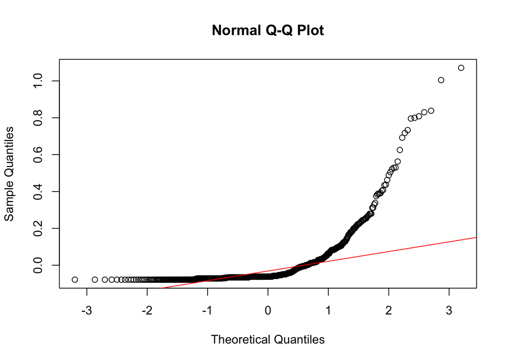

```r
# Create the Dataframe
Precip_Daily_COVID <- summarySE(Weather_Daily_COVID,
                                measurevar= "rain",
                                groupvars=c("Month", "Year", "Date"))

# Build the linear model
precip_model <- lm(rain ~ Year, data = Precip_Daily_COVID)

# Create a QQ plot of residuals
qqnorm(residuals(precip_model))
qqline(residuals(precip_model), col = "red")
```

```r
# Shapiro-wilk test
shapiro.test(residuals(precip_model))
```

```
##
##  Shapiro-Wilk normality test
##
## data:  residuals(precip_model)
## W = 0.54418, p-value < 2.2e-16
```

Residuals for wind speeds:

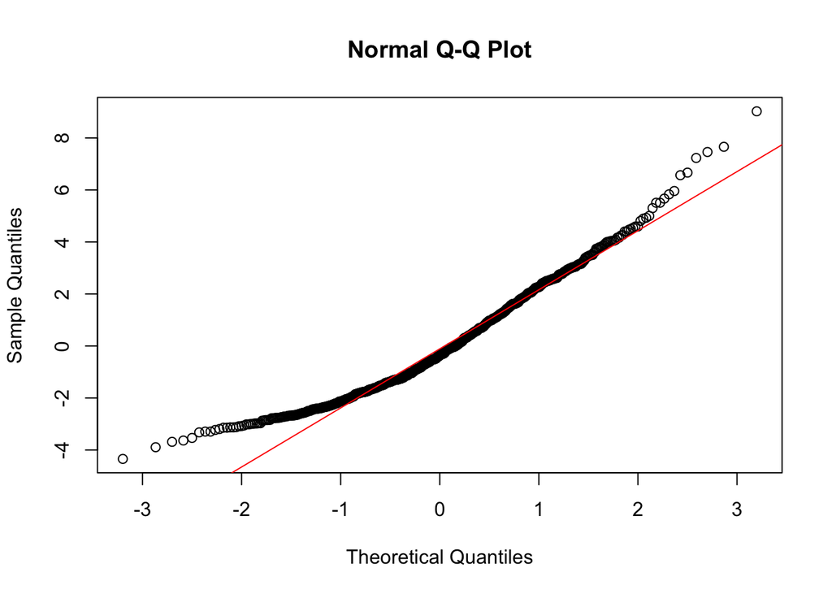

```r
# Create the Dataframe
Wind_Daily_COVID <- summarySE(Weather_Daily_COVID,
                              measurevar= "wdsp",
                              groupvars=c("Month", "Year", "Date"))

# Build the linear model
wind_model <- lm(wdsp ~ Year, data = Wind_Daily_COVID)

# Create a QQ plot of residuals
qqnorm(residuals(wind_model))
qqline(residuals(wind_model), col = "red")
```

```r
# Shapiro-wilk test
shapiro.test(residuals(wind_model))
```

```
##
##  Shapiro-Wilk normality test
##
## data:  residuals(wind_model)
## W = 0.95826, p-value = 1.712e-13
```

Since the data is not normally distributed, we will use non-parametric statistical tests to calculate differences between 2017-2019, and 2020 experimental timeframes.

# Precipitation

Create the precipitation dataframe:

```r
# Dataframe
Precip_Daily_COVID <- Precip_Daily_COVID %>%
  mutate(month = case_when(
    Month == '01' ~ 'January',
    Month == '02' ~ 'February',
    Month == '03' ~ 'March',
    Month == '04' ~ 'April',
    Month == '05' ~ 'May',
    Month == '06' ~ 'June',))
```

Precipitaion barplots:

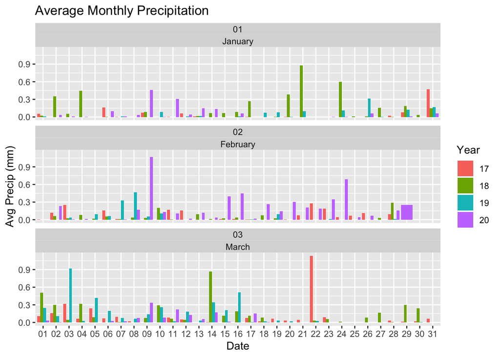

```r
# Create sub-frames to allow for easier graphical visualization
Precip_17_20_1 <- Precip_Daily_COVID %>%
  filter(Month < '04')
Precip_17_20_2 <- Precip_Daily_COVID %>%
  filter(Month > '03')

# Barplot plate 1
multi_precip1 <- ggplot(data = Precip_17_20_1, aes(Date, rain, position = "dodge", fill = Year)) +
  geom_bar(position="dodge", stat = "identity")+
  labs(x = 'Date',
       y = 'Avg Precip (mm)',
       title = "Average Monthly Precipitation",
       color = "Year")+
  facet_wrap(~ Month+month, dir = 'v')+
  theme(
    strip.text.x = element_text(margin = margin(2, 0, 2, 0)))
multi_precip1
```

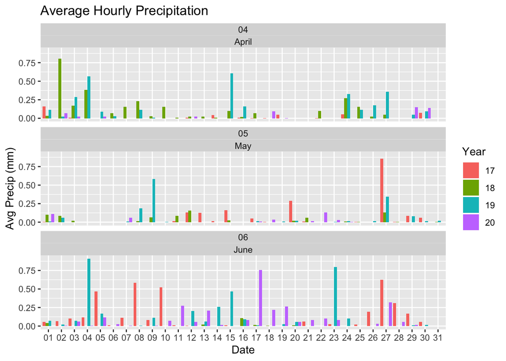

```r
# Barplot plate 2
multi_precip2 <- ggplot(data = Precip_17_20_2, aes(Date, rain, position = "dodge", fill = Year)) +
  geom_bar(position="dodge", stat = "identity")+
  labs(x = 'Date',
       y = 'Avg Precip (mm)',
       title = "Average Hourly Precipitation",
       color = "Year")+
  facet_wrap(~ Month+month, dir = 'v')+
  theme(
    strip.text.x = element_text(margin = margin(2, 0, 2, 0)))
multi_precip2
```

Monthly precipitaion averages:

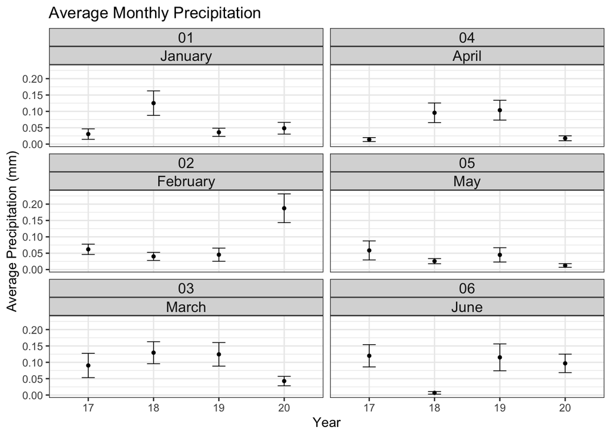

```r
# Create singular dataframe with monthly averages
Precip_Daily_COVID_bar <- summarySE(Precip_Daily_COVID,
                              measurevar= "rain",
                              groupvars=c("Month", "Year"))

# Add month ID to facilitate plate visualization
Precip_Daily_COVID_bar <- Precip_Daily_COVID_bar %>%
  mutate(month = case_when(
    Month == '01' ~ 'January',
    Month == '02' ~ 'February',
    Month == '03' ~ 'March',
    Month == '04' ~ 'April',
    Month == '05' ~ 'May',
    Month == '06' ~ 'June',))

# Produce plot
multi_precip <- ggplot(Precip_Daily_COVID_bar, aes(x=Year, y=rain)) +
  geom_point(stat="identity",
           size=1) +      # Thinner lines
  geom_errorbar(aes(ymin=rain-se, ymax=rain+se),
                size=.3,    # Thinner lines
                width=.2,
                position=position_dodge(.9)) +
  labs(x = "Year",
       y = "Average Precipitation (mm)",
       title = "Average Monthly Precipitation") +
  theme_bw()+
  facet_wrap(~ Month+month, dir = 'v')+
  theme(
    strip.text.x = element_text(margin = margin(2, 0, 2, 0), size = 12))
multi_precip
```

Monthly precipitation statistics:

```r
# Create a separate dataframe for each month
Jan_Daily_Precip <- Precip_Daily_COVID %>%
  filter(Month == '01')
Feb_Daily_Precip <- Precip_Daily_COVID %>%
  filter(Month == '02')
Mar_Daily_Precip <- Precip_Daily_COVID %>%
  filter(Month == '03')
Apr_Daily_Precip <- Precip_Daily_COVID %>%
  filter(Month == '04')
May_Daily_Precip <- Precip_Daily_COVID %>%
  filter(Month == '05')
Jun_Daily_Precip <- Precip_Daily_COVID %>%
  filter(Month == '06')

# Non-parametric kruskal-wallis tests for each month
Jan_rain.w <- kruskal.test(rain ~ Year, data = Jan_Daily_Precip)
Jan_rain.w
```

```
##
##  Kruskal-Wallis rank sum test
##
## data:  rain by Year
## Kruskal-Wallis chi-squared = 9.5255, df = 3, p-value = 0.02306
```

```r
Feb_rain.w <- kruskal.test(rain ~ Year, data = Feb_Daily_Precip)
Feb_rain.w
```

```
##
##  Kruskal-Wallis rank sum test
##
## data:  rain by Year
## Kruskal-Wallis chi-squared = 18.771, df = 3, p-value = 0.000305
```

```r
Mar_rain.w <- kruskal.test(rain ~ Year, data = Mar_Daily_Precip)
Mar_rain.w
```

```
##
##  Kruskal-Wallis rank sum test
##
## data:  rain by Year
## Kruskal-Wallis chi-squared = 8.6163, df = 3, p-value = 0.03485
```

```r
Apr_rain.w <- kruskal.test(rain ~ Year, data = Apr_Daily_Precip)
Apr_rain.w
```

```
##
##  Kruskal-Wallis rank sum test
##
## data:  rain by Year
## Kruskal-Wallis chi-squared = 17.223, df = 3, p-value = 0.0006358
```

```r
May_rain.w <- kruskal.test(rain ~ Year, data = May_Daily_Precip)
May_rain.w
```

```
##
##  Kruskal-Wallis rank sum test
##
## data:  rain by Year
## Kruskal-Wallis chi-squared = 4.6174, df = 3, p-value = 0.2021
```

```r
Jun_rain.w <- kruskal.test(rain ~ Year, data = Jun_Daily_Precip)
Jun_rain.w
```

```
##
##  Kruskal-Wallis rank sum test
##
## data:  rain by Year
## Kruskal-Wallis chi-squared = 25.159, df = 3, p-value = 1.43e-05
```

# Wind Speed

Create the windspeed dataframe:

```r
# Add month IDs to wind speed master dataframe
Wind_Daily_COVID <- Wind_Daily_COVID %>%
  mutate(month = case_when(
    Month == '01' ~ 'January',
    Month == '02' ~ 'February',
    Month == '03' ~ 'March',
    Month == '04' ~ 'April',
    Month == '05' ~ 'May',
    Month == '06' ~ 'June',))

# Create separate dataframes for 2017-2020
Wind_17 <- Wind_Daily_COVID %>%
  filter(Year == '17')
Wind_18 <- Wind_Daily_COVID %>%
  filter(Year == '18')
Wind_19 <- Wind_Daily_COVID %>%
  filter(Year == '19')
Wind_20 <- Wind_Daily_COVID %>%
  filter(Year == '20')
Wind_20 <- Wind_20[-60,]

# Re-bind individual dataframes into a master for linear plotting
Wind_17_20 <- cbind(Wind_17, Wind_18, Wind_19, Wind_20)
Wind_17_20 <- Wind_17_20[,-c(9:11, 18:20, 27:29)]
```

Windspeed barplots:

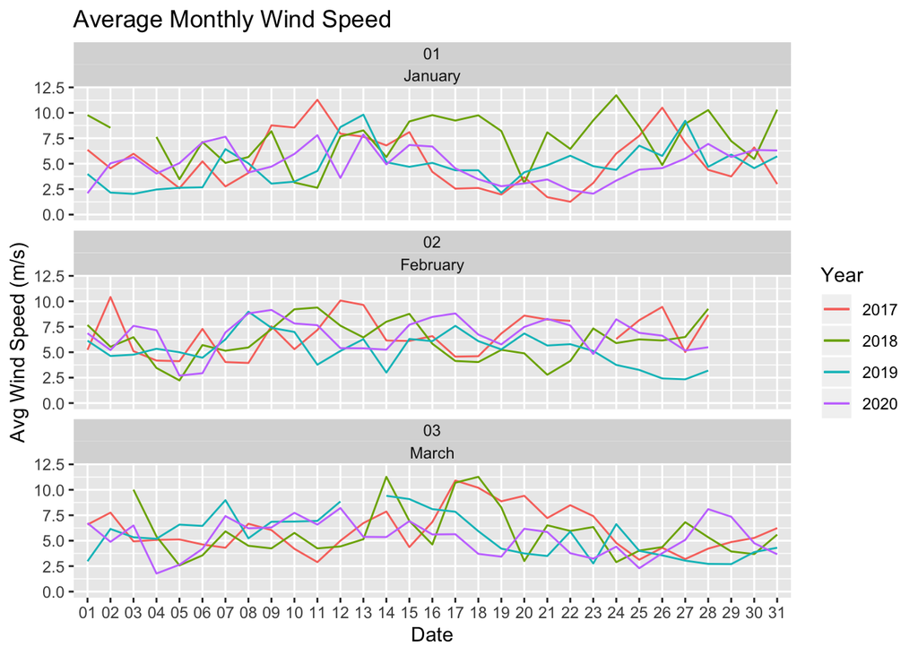

```r
# Create sub-frames to allow for easier graphical visualization
Wind_17_20_1 <- Wind_17_20 %>%
  filter(Month < '04')
Wind_17_20_2 <- Wind_17_20 %>%
  filter(Month > '03')

# Line plot plate 1
multi_wind1 <- ggplot(data = Wind_17_20_1, aes(Date)) +
  geom_line(aes(y = wdsp, group = 1, colour = "2017")) +
  geom_line(aes(y = wdsp.1, group = 1, colour = "2018")) +
  geom_line(aes(y = wdsp.2, group = 1, colour = "2019")) +
  geom_line(aes(y = wdsp.3, group = 1, colour = "2020")) +
  labs(x = 'Date',
       y = 'Avg Wind Speed (m/s)',
       title = "Average Monthly Wind Speed",
       color = "Year")+
  ylim(0,12)+
  facet_wrap(~ Month+month, dir = 'v')+
  theme(
    strip.text.x = element_text(margin = margin(2, 0, 2, 0)))
multi_wind1
```

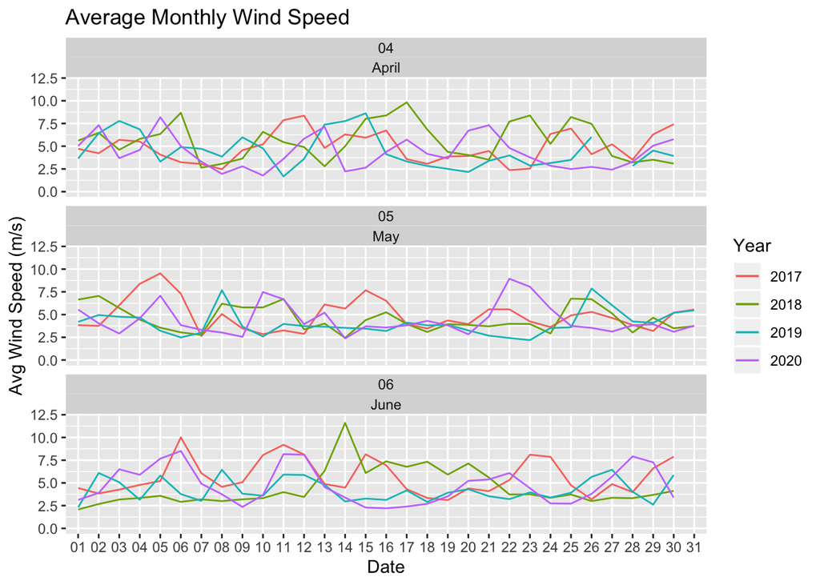

```r
# Line plot plate 2
multi_wind2 <- ggplot(data = Wind_17_20_2, aes(Date)) +
  geom_line(aes(y = wdsp, group = 1, colour = "2017")) +
  geom_line(aes(y = wdsp.1, group = 1, colour = "2018")) +
  geom_line(aes(y = wdsp.2, group = 1, colour = "2019")) +
  geom_line(aes(y = wdsp.3, group = 1, colour = "2020")) +
  labs(x = 'Date',
       y = 'Avg Wind Speed (m/s)',
       title = "Average Monthly Wind Speed",
       color = "Year")+
  ylim(0,12)+
  facet_wrap(~ Month+month, dir = 'v')+
  theme(
    strip.text.x = element_text(margin = margin(2, 0, 2, 0)))
multi_wind2
```

Monthly wind averages:

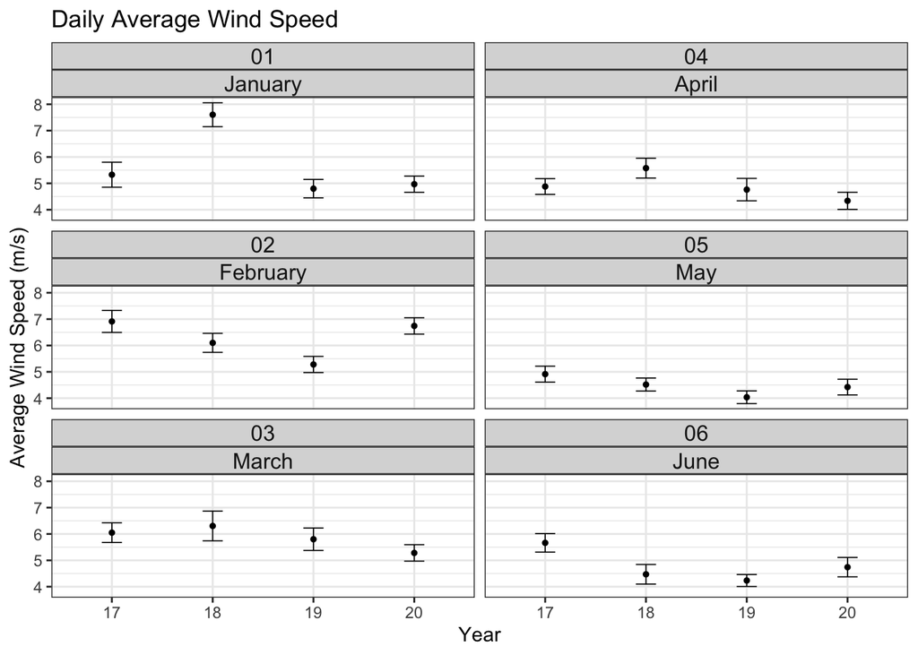

```r
# Create singular dataframe with monthly averages
Wind_Daily_COVID_bar <- summarySE(Wind_Daily_COVID,
                              measurevar= "wdsp",
                              groupvars=c("Month", "Year"))

# Add month IDs to wind speed master dataframe
Wind_Daily_COVID_bar <- Wind_Daily_COVID_bar %>%
  mutate(month = case_when(
    Month == '01' ~ 'January',
    Month == '02' ~ 'February',
    Month == '03' ~ 'March',
    Month == '04' ~ 'April',
    Month == '05' ~ 'May',
    Month == '06' ~ 'June',))

# Produce plot
multi_Wind <- ggplot(Wind_Daily_COVID_bar, aes(x=Year, y=wdsp)) +
  geom_point(stat="identity",
             size=1) +      # Thinner lines
  geom_errorbar(aes(ymin=wdsp-se, ymax=wdsp+se),
                size=.3,    # Thinner lines
                width=.2,
                position=position_dodge(.9)) +
  labs(x = "Year",
       y = "Average Wind Speed (m/s)",
       title = "Daily Average Wind Speed") +
  theme_bw()+
  facet_wrap(~ Month+month, dir = 'v')+
  theme(
    strip.text.x = element_text(margin = margin(2, 0, 2, 0), size = 12))
multi_Wind
```

Monthly wind statistics:

```r
# Create a separate dataframe for each month:
Jan_Daily_Wind <- Wind_Daily_COVID %>%
  filter(Month == '01')
Feb_Daily_Wind <- Wind_Daily_COVID %>%
  filter(Month == '02')
Mar_Daily_Wind <- Wind_Daily_COVID %>%
  filter(Month == '03')
Apr_Daily_Wind <- Wind_Daily_COVID %>%
  filter(Month == '04')
May_Daily_Wind <- Wind_Daily_COVID %>%
  filter(Month == '05')
Jun_Daily_Wind <- Wind_Daily_COVID %>%
  filter(Month == '06')

# Non-parametric kruskal-wallis tests for each month
Jan_wdsp.w <- kruskal.test(wdsp ~ Year, data = Jan_Daily_Wind)
Jan_wdsp.w
```

```
##
##  Kruskal-Wallis rank sum test
##
## data:  wdsp by Year
## Kruskal-Wallis chi-squared = 22.94, df = 3, p-value = 4.156e-05
```

```r
Feb_wdsp.w <- kruskal.test(wdsp ~ Year, data = Feb_Daily_Wind)
Feb_wdsp.w
```

```
##
##  Kruskal-Wallis rank sum test
##
## data:  wdsp by Year
## Kruskal-Wallis chi-squared = 11.748, df = 3, p-value = 0.008297
```

```r
Mar_wdsp.w <- kruskal.test(wdsp ~ Year, data = Mar_Daily_Wind)
Mar_wdsp.w
```

```
##
##  Kruskal-Wallis rank sum test
##
## data:  wdsp by Year
## Kruskal-Wallis chi-squared = 1.4557, df = 3, p-value = 0.6925
```

```r
Apr_wdsp.w <- kruskal.test(wdsp ~ Year, data = Apr_Daily_Wind)
Apr_wdsp.w
```

```
##
##  Kruskal-Wallis rank sum test
##
## data:  wdsp by Year
## Kruskal-Wallis chi-squared = 6.2601, df = 3, p-value = 0.09962
```

```r
May_wdsp.w <- kruskal.test(wdsp ~ Year, data = May_Daily_Wind)
May_wdsp.w
```

```
##
##  Kruskal-Wallis rank sum test
##
## data:  wdsp by Year
## Kruskal-Wallis chi-squared = 5.3249, df = 3, p-value = 0.1495
```

```r
Jun_wdsp.w <- kruskal.test(wdsp ~ Year, data = Jun_Daily_Wind)
Jun_wdsp.w
```

```
##
##  Kruskal-Wallis rank sum test
##
## data:  wdsp by Year
## Kruskal-Wallis chi-squared = 11.892, df = 3, p-value = 0.007762
```

The result of the analyses indicate that the month of May does not significantly differ in average hourly precipitation or average hourly wind speeds across the years 2017 2020.